# HW8

**In this Notebook we work on Titanic passengers database and make predictions on their survival. We use scikit-learn package, please feel free to learn classification in scikit from here https://scikit-learn.org/stable/supervised_learning.html#supervised-learning Most of the functions needed for the homework are in the notebook, please look at the arguments for each function and play with them to improve your understanding**

```python
from __future__ import absolute_import, division, print_function, unicode_literals

import numpy as np
import pandas as pd
from IPython.display import clear_output
from matplotlib import pyplot as plt
from sklearn.ensemble import AdaBoostClassifier
from sklearn.tree import DecisionTreeClassifier
from sklearn.svm import SVC
from sklearn import metrics
# Load dataset.
dftrain = pd.read_csv('https://storage.googleapis.com/tf-datasets/titanic/train.csv')
dfeval = pd.read_csv('https://storage.googleapis.com/tf-datasets/titanic/eval.csv')
y_train = dftrain.pop('survived')
y_eval = dfeval.pop('survived')
```

**Explore the dataset by looking at the features. For improving the accuracy you can play with features as well, if you feel some of the features are not needed, you can drop them**

```python
dftrain.head()
```

|  | sex | age | n_siblings_spouses | parch | fare | class | deck | embark_town | alone |
| --- | --- | --- | --- | --- | --- | --- | --- | --- | --- |
| 0 | male | 22.0 | 1 | 0 | 7.2500 | Third | unknown | Southampton | n |
| 1 | female | 38.0 | 1 | 0 | 71.2833 | First | C | Cherbourg | n |
| 2 | female | 26.0 | 0 | 0 | 7.9250 | Third | unknown | Southampton | y |
| 3 | female | 35.0 | 1 | 0 | 53.1000 | First | C | Southampton | n |
| 4 | male | 28.0 | 0 | 0 | 8.4583 | Third | unknown | Queenstown | y |

```python
dfeval.head()
```

|  | sex | age | n_siblings_spouses | parch | fare | class | deck | embark_town | alone |
| --- | --- | --- | --- | --- | --- | --- | --- | --- | --- |
| 0 | male | 35.0 | 0 | 0 | 8.0500 | Third | unknown | Southampton | y |
| 1 | male | 54.0 | 0 | 0 | 51.8625 | First | E | Southampton | y |
| 2 | female | 58.0 | 0 | 0 | 26.5500 | First | C | Southampton | y |
| 3 | female | 55.0 | 0 | 0 | 16.0000 | Second | unknown | Southampton | y |
| 4 | male | 34.0 | 0 | 0 | 13.0000 | Second | D | Southampton | y |

**Analyse the dataset, here you find the count, statistics of dataset**

```python
dftrain.describe()
```

|  | age | n_siblings_spouses | parch | fare |
| --- | --- | --- | --- | --- |
| count | 627.000000 | 627.000000 | 627.000000 | 627.000000 |
| mean | 29.631308 | 0.545455 | 0.379585 | 34.385399 |
| std | 12.511818 | 1.151090 | 0.792999 | 54.597730 |
| min | 0.750000 | 0.000000 | 0.000000 | 0.000000 |
| 25% | 23.000000 | 0.000000 | 0.000000 | 7.895800 |
| 50% | 28.000000 | 0.000000 | 0.000000 | 15.045800 |
| 75% | 35.000000 | 1.000000 | 0.000000 | 31.387500 |
| max | 80.000000 | 8.000000 | 5.000000 | 512.329200 |

**Look at labeled data of both training and evaluation set**

```python
y_train.head()
```

```
0    0
1    1
2    1
3    1
4    0
Name: survived, dtype: int64
```

```python
y_eval.head()
```

```
0    0
1    0
2    1
3    1
4    1
Name: survived, dtype: int64
```

**In the next few plots you can observe few more things in the dataset like distribution of age of passengers. Make good observations on the features, it might help you push your prediction accuracy**

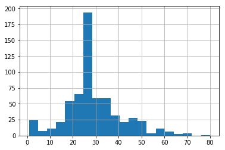

```python
dftrain.age.hist(bins=20)
plt.show()
```

**Make some observations on the unfortundate :( data set**

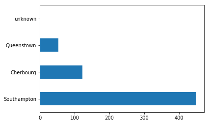

```python
dftrain.embark_town.value_counts().plot(kind='barh')
plt.show()
```

**Survived passengers for each class**

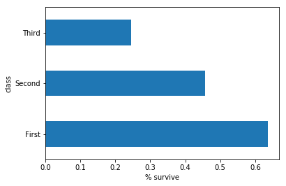

```python
pd.concat([dftrain, y_train], axis=1).groupby('class').survived.mean().plot(kind='barh').set_xlabel('% survive')
plt.show()
```

**Alright! lets get started! by now you must be wondering how to run learning algorithms on categorial features(we care only about numbers right!). Dataset has categorial features like embark_town, deck, class etc. These are strings but all the algorithms need numericals right. So, we have to change categorial features to numerical features. There are three different ways to do that, here we present one and the easiest way to do that**

```python
# Get dummies
dftrain = pd.get_dummies(dftrain, prefix_sep='_', drop_first=False)
dfeval = pd.get_dummies(dfeval, prefix_sep='_', drop_first=False)
dftrain.shape
dfeval.shape
```

```
(264, 22)
```

**Here we are dropping one of the features to align training and evaluation datasets, you can use this to drop features you might consider unnecessary**

```python
dftrain = dftrain.drop(columns="deck_G")
```

```python
dftrain.shape
```

```
(627, 22)
```

```python
dfeval.shape
```

```
(264, 22)
```

**Decision Tree Classification**

```python
 dtc = DecisionTreeClassifier(max_depth=1)
dtc.fit(dftrain, y_train)
y_pred = dtc.predict(dfeval)
print("Accuracy:",metrics.accuracy_score(y_eval, y_pred)*100,"%")
```

```
Accuracy: 74.24242424242425 %
```

**Adaptive boosting for Decision Tree Classification**

```python
from sklearn.model_selection import GridSearchCV


parameters = {'base_estimator__max_depth' : [1,2,3,4,5,10]}

abc = AdaBoostClassifier(base_estimator = DecisionTreeClassifier(),n_estimators=50,
                         learning_rate=1)

clf = GridSearchCV(abc, parameters)

# Train Adaboost Classifer
clf.fit(dftrain, y_train)

#Predict the response for test dataset
y_pred = clf.predict(dfeval)
print(clf.best_params_)
print("Accuracy:",metrics.accuracy_score(y_eval, y_pred)*100,"%")
```

```
{u'base_estimator__max_depth': 1}
Accuracy: 77.65151515151516 %
```

**In case of adaptive boosting for decision tree classification, the max depth has various values in base_estimator__max_depth, and I play around with the values a little bit. Turns out the best accuracy is achieved with max_depth =1** **bold text**

```python
abc = AdaBoostClassifier(DecisionTreeClassifier(max_depth=3),n_estimators=50,
                         learning_rate=1)
# Train Adaboost Classifer
model = abc.fit(dftrain, y_train)

#Predict the response for test dataset
y_pred = model.predict(dfeval)

print("Accuracy:",metrics.accuracy_score(y_eval, y_pred)*100,"%")
```

```
Accuracy: 76.89393939393939 %
```

**Linear SVM classifier**

```python
svclassifier = SVC(kernel='linear')
svclassifier.fit(dftrain, y_train)
y_pred = svclassifier.predict(dfeval)
print("Accuracy:",metrics.accuracy_score(y_eval, y_pred)*100,"%")
```

```
Accuracy: 75.37878787878788 %
```

```python
svc=SVC(probability=True, kernel='rbf')

# Create adaboost classifer object
abc =AdaBoostClassifier(n_estimators=90, base_estimator=svc,learning_rate=.01)

# Train Adaboost Classifer
model = abc.fit(dftrain, y_train)

#Predict the response for test dataset
y_pred = model.predict(dfeval)
print("Accuracy:",metrics.accuracy_score(y_eval, y_pred)*100,"%")
```

```
Accuracy: 73.86363636363636 %
```

**Use SVM classifier with polynomial or radial basis function as kernel and later apply boosting and share your observations**

```python
svclassifier = SVC(gamma='scale',kernel='poly', degree = 1, shrinking = True, probability=True)
svclassifier.fit(dftrain, y_train)
y_pred = svclassifier.predict(dfeval)
```

```python
# Create adaboost classifer object
abc =AdaBoostClassifier(n_estimators=90, base_estimator=svclassifier,learning_rate=.01)

# Train Adaboost Classifer
model = abc.fit(dftrain, y_train)

#Predict the response for test dataset
y_pred = model.predict(dfeval)
print("Accuracy:",metrics.accuracy_score(y_eval, y_pred)*100,"%")
```

```
Accuracy: 67.42424242424242 %
```

```python
svclassifier = SVC(kernel='rbf')
svclassifier.fit(dftrain, y_train)
y_pred = svclassifier.predict(dfeval)
print("Accuracy:",metrics.accuracy_score(y_eval, y_pred)*100,"%")
```

```
Accuracy: 71.96969696969697 %
```

```python
print("Accuracy:",metrics.accuracy_score(y_eval, y_pred)*100,"%")
```

```
Accuracy: 71.96969696969697 %
```

**It's all yours now, get the best possible accuracy in doing so understand the concepts we learnt in class. Hold on fellas, one more thing, don't push yourself so hard to get 100% though!**

```python
from sklearn.model_selection import GridSearchCV


parameters = {'base_estimator__max_depth' : [1,2,3,4,5,10], 'learning_rate' : [0.01, 0.1, 0.05], 'n_estimators' : [20,30,50,100]}

abc = AdaBoostClassifier(base_estimator = DecisionTreeClassifier())

clf = GridSearchCV(abc, parameters)

# Train Adaboost Classifer
clf.fit(dftrain, y_train)

#Predict the response for test dataset
y_pred = clf.predict(dfeval)
print(clf.best_params_)
print("Accuracy:",metrics.accuracy_score(y_eval, y_pred)*100,"%")
```

```
{u'n_estimators': 20, u'learning_rate': 0.1, u'base_estimator__max_depth': 2}
Accuracy: 78.03030303030303 %
```

```python
abc = AdaBoostClassifier(base_estimator = DecisionTreeClassifier(max_depth=6),n_estimators=40)

#clf = GridSearchCV(abc, parameters)

# Train Adaboost Classifer
abc.fit(dftrain, y_train)

#Predict the response for test dataset
y_pred = abc.predict(dfeval)
#print(clf.best_params_)
print("Accuracy:",metrics.accuracy_score(y_eval, y_pred)*100,"%")
```

[output not shown]